# Improved marketing decision making in a customer churn prediction context using generalized additive models - ScienceDirect

## Outline

1. Abstract
2. Keywords
3. 1. Introduction
4. 2. Methodology
5. 3. Empirical validation
6. 4. Managerial implications
7. 5. Conclusion and directions for further research
8. Acknowledgments
9. Appendix A. Overview of the explicative variables
10. Appendix B. Visualization of MOD_GAM
11. References

## Tables (8)

1. Table 1
2. Table 2
3. Table 3
4. Table 4
5. Table 5
6. Table

## [Expert Systems with Applications](https://www.sciencedirect.com/science/journal/09574174)

[Volume 37, Issue 3](https://www.sciencedirect.com/science/journal/09574174/37/3), 15 March 2010, Pages 2132-2143

# Improved marketing decision making in a customer churn prediction context using generalized additive models

[KristofCoussement<sup>a</sup><sup>b</sup>](https://www.sciencedirect.com/science/article/pii/S0957417409007325?via%3Dihub#!)[Dries F.Benoit<sup>b</sup>](https://www.sciencedirect.com/science/article/pii/S0957417409007325?via%3Dihub#!)[DirkVan den Poel<sup>b</sup>](https://www.sciencedirect.com/science/article/pii/S0957417409007325?via%3Dihub#!)

https://doi.org/10.1016/j.eswa.2009.07.029[Get rights and content](https://s100.copyright.com/AppDispatchServlet?publisherName=ELS&contentID=S0957417409007325&orderBeanReset=true)

## Abstract

Nowadays, companies are investing in a well-considered CRM strategy. One of the cornerstones in CRM is customer churn prediction, where one tries to predict whether or not a customer will leave the company. This study focuses on how to better support marketing decision makers in identifying risky customers by using Generalized Additive Models (GAM). Compared to Logistic Regression, GAM relaxes the linearity constraint which allows for complex non-linear fits to the data. The contributions to the literature are three-fold: (i) it is shown that GAM is able to improve marketing decision making by better identifying risky customers; (ii) it is shown that GAM increases the interpretability of the churn model by visualizing the non-linear relationships with customer churn identifying a quasi-exponential, a U, an inverted U or a complex trend and (iii) marketing managers are able to significantly increase business value by applying GAM in this churn prediction context.

## Keywords

Customer Relationship Management (CRM)

Churn modeling

Marketing decision making

Generalized Additive Models (GAM)

## 1. Introduction

Today, the business environment is characterized by fierce competition and saturated markets. In this context, companies increasingly derive revenue from the creation and enhancement of long-term relationships with their customers. This move towards a customer-centric approach to marketing, coupled with the increasing availability of customer-transactional data has made Customer Relationship Management (CRM) the leading strategy for marketing decision makers and this is reflected in firms’ significant investments in CRM (Reinartz and Kumar, 2002, Teo et al., 2006). Companies realize that their existing customer database is their most valuable asset (Athanassopoulos, 2000, Jones et al., 2000, Thomas, 2001). It has been shown that it is more profitable to keep and satisfy existing customers than to constantly attract new customers who are characterized by a high attrition rate (Reinartz & Kumar, 2003). It is even suggested that it costs 12 times more to gain a new customer than to retain an existing one (Torkzadeh, Chang, & Hansen, 2006). Moreover, retained customers produce higher revenues and margin than new customers (Reichheld & Sasser, 1990).

It is clear that customer retention rates are important metrics in CRM (Hoekstra, Leeflang, & Wittink, 1999), resulting in an increasing number of customer churn related papers (e.g. Burez and Van den Poel, 2009, Coussement and Van den Poel, 2009). Predicting churn enables the elaboration of targeted retention strategies to limit the losses and to improve marketing decisions (Shaffer & Zhang, 2002). For example, specific incentives may be offered to the most risky customer segments, i.e. the most inclined to leave the company, with the hope that they remain loyal (Burez & Van den Poel, 2007). Two possible outcomes are observed: the customer churned or he/she stayed with the company. So, technically spoken, customer churn modeling is a binary classification problem. Moreover, for the prediction of customer churn using the information stored in the data warehouse one needs tools that can handle large amounts of data, i.e. data-mining tools (Shaw, Subramaniam, Tan, & Welge, 2001).

A broad range of data mining techniques have been used in the past, but one of the most popular models in the churn context remains the (binary) Logit model (Lemmens & Croux, 2006). This model has been used extensively in marketing decision making to model churn problems (e.g Buckinx and Van den Poel, 2005, Hwang and Euiiho Suh, 2004, Kim and Yoon, 2004). The popularity of Logistic Regression is not surprising since the model has some outspoken advantages. First of all, the method is able to combine relative simplicity and good performance. The parameter estimates of the Logit model are interpretable in terms of odds ratios which facilitates full understanding of the results. Moreover, the technique is relatively robust (Buckinx & Van den Poel, 2005), while its popularity is reflected in the availability in almost all statistical software packages. However, as often, one of the advantages can also be considered as a disadvantage. The simplicity of the model is achieved by assuming that the functional form of the dependence on the explanatory variables is known. However, the functional form is seldom known in practice. If the functional form is misspecified then the estimates of the coefficients and the inferences based on them are misleading (Horowitz & Savin, 2001). In addition, with Logistic Regression, a linear relationship is modeled on the data, which is an oversimplification of the real relationship in the data (Allison, 1999). It is possible to relax these restrictive assumptions by applying the Generalized Additive Models (GAM) approach.

The GAM approach has at least two distinct advantages compared to Logistic Regression. First, by relaxing the usual assumptions it becomes possible to uncover (non-linear) structures in the data that otherwise might be missed. These structures often give substantial new insights into the effects of the covariates. Furthermore, since the GAM approach allows for more complex relationships between the dependent variable and the covariates, more accurate predictions are likely (Hastie & Tibshirani, 1986). The GAM approach has shown its relevance in a broad range of different research domains ranging from biology (e.g. Jowett, Parkyn, & Richardson, 2008) over cancer research (e.g. Lee et al., 2007) and supply-chain management (e.g. Cakir, 2009). However, only very few marketing-related studies have used a related non- or semi-parametric methodology (e.g. Kalyanam and Shively, 1998, Kumar et al., 1998, Shively et al., 2000). Moreover, to the best of our knowledge this is the first study in a customer churn context that evaluates and uses GAM models.

This study contributes to the existing literature in several ways. Three distinct perspectives on GAM models in the current churn context are elaborated. First, a comparison in terms of predictive performance is made between the popular Logistic Regression model and the GAM approach. Second, it is shown that relaxing the linearity assumption results in a much richer insight into the effects of the covariates which helps decision makers in a thorough understanding of the churn problem of their company. Finally, it is shown how GAM models increase business value of the company. The added value of the GAM approach is therefore shown in monetary terms based on a real-life business setting.

The remainder of this paper is organized as follows. Section 2 focuses on the methodology behind both the logistic model and the GAM approach. The evaluation criteria used in the empirical part of this study are explained in the same section. Section 3 applies the proposed methodology to a real-world churn setting, i.e. the newspaper case. Section 4 treats the managerial implication of the proposed methodology and finally, Section 5 gives conclusions and directions for further research.

## 2. Methodology

### 2.1. Base learner

The methodological link between the Logistic Regression and the GAM approach is explained starting from the Generalized Linear Model (GLM) framework. The most common representation of the GLM is as follows (Tabachnick & Fidell, 1996):(1)$E(Y)=μ=g(X′β)$with *E*(*Y*) representing the expected value of *Y*, *X′β* is a linear combination of the data with unknown parameters *β* and *g* is the link function. As Eq. (1) shows, each outcome of the dependent variable *Y* is assumed to be generated from a particular distribution function. Different choices of distribution function and link function result in different statistical techniques. For example, the normal distribution in combination with the identity link function results in the normal multiple regression model. When the responses *Y* are binary, the distribution function is the binomial distribution and the interpretation of *μ<sub>i</sub>* is then the probability, *p<sub>i</sub>*, of *Y<sub>i</sub>* taking on the value one. A Logistic Regression model is then obtained by applying the logit link function by(2)$logit{P(X)}≡logP(X)1-P(X)=α+∑j=1pβj′Xj$with *P*(*X*) = *Pr*(*Y* = 1|*X*). The parameter vector *β* is estimated from observations (*y*, *x*) and this can be done using maximum likelihood among others. More technical details on Logistic Regression are found in Anderson (1983).

### 2.2. Generalized additive models

An attractive alternative to Logistic Regression is Generalized Additive Models (GAM) (Hastie and Tibshirani, 1986, Hastie and Tibshirani, 1987, Hastie and Tibshirani, 1990). Additive Logistic Regression relaxes the linearity constraint and suggests a nonparametric fit to the data. In other words, the regression function is modeled in a nonparametric way and the data itself decides on the functional form. However, Hastie and Tibshirani (1990) argue that nonparametric methods perform worse when the number of explicative variables increases, because the sparseness of the data inflates the variance of the estimates. This is often referred to as the curse of dimensionality (Bellman, 1961). It was Stone (1985) who proposed additive models to approximate the multivariate regression function. Consequently, the curse of dimensionality is avoided since each individual additive term is estimated using a univariate smoother. Hastie and Tibshirani (1990) pick up the additive model principle by extending the GLM framework.

This study gives a general overview on the GAM principle. For more details, we kindly refer to Hastie and Tibshirani, 1986, Hastie and Tibshirani, 1987, Hastie and Tibshirani, 1990, Hastie et al., 2001. Suppose that *Y* is the response variable with binary target labels and *X*<sub>1</sub>, *X*<sub>2</sub>, … , *X<sub>p</sub>* is a set of independent variables, GAM generalize the Logistic Regression principle by replacing the linear predictor $∑j=1pβjXj$ in Eq. (2) with an other additive component where(3)$logitP(X)≡logP(X)1-P(X)=α+∑j=1psj(Xj)$with *s*<sub>1</sub>(.), *s*<sub>2</sub>(.), … , *s<sub>p</sub>*(.) as smooth functions. This study uses smoothing splines for *s*<sub>1</sub>(.), *s*<sub>2</sub>(.), … , *s<sub>p</sub>*(.) to estimate the nonparametric trend for the dependence of the logit on *X*<sub>1</sub>, *X*<sub>2</sub>, … , *X<sub>p</sub>*. A smoothing spline solves the following optimization problem: among all functions *η*(*x*) with continuous second order derivatives, find the function that minimizes the penalized residual sum of squares(4)$∑i=1n(yi-η(xi))2+λ∫ab(η″(t))2dt$where *λ* is a fixed constant and *a* ⩽ *x*<sub>1</sub> ⩽ *x*<sub>2</sub> ⩽ ⋯ ⩽ *x<sub>n</sub>* ⩽ *b*. The goodness-of-fit is measured by the first part of Eq. (4), while the second term is a penalty term that penalizes curvature in the function by the smoothing parameter *λ*. The complexity of *η*(*x*) is measured by *λ* and it is inversely related to the degrees of freedom (*df*). If *λ* is small (i.e. the *df* are large), *η*(*x*) is any function that approaches an interpolation to the data, when *λ* is large (i.e. the *df* are small), *η*(*x*) is closely related to a simple least squares fit. It is shown that an explicit and unique minimizer for Eq. (4) exists, i.e. a natural cubic spline with knots at the unique values of *x<sub>i</sub>* (Hastie & Tibshirani, 1990).

In order to optimize the GAM, the local scoring algorithm (Hastie & Tibshirani, 1986) is applied, while the backfitting algorithm of (Friedman & Stuetzle, 1981) is used to estimate the additive models. The current study follows the recommendation of Hastie et al. (2001) to use a *λ* corresponding to four degrees of freedom, because it is shown that a small number of *df* fits most datasets very well.

### 2.3. Feature selection

Feature selection techniques are often used in the context of churn modeling (e.g. Coussement & Van den Poel, 2008). It is the process of choosing a subset of the original predictive variables by eliminating variables that are either redundant or possess little predictive information. This significantly improves the comprehensibility of resulting models and makes resulting models generalize better (Kim, 2006). In addition, selection techniques defy the curse of dimensionality in order to improve prediction performance (Guyon & Elisseef, 2003). Moreover, extracting a comprehensive subset of relevant predictor variables is critical for decision makers who want to build marketing strategies based on key drivers of customer response. A forward selection is used within this research setting. The choice for this relatively standard selection technique makes it easy to replicate results with most statistical software packages (Kim, 2006).

### 2.4. Evaluation criteria

It is essential to evaluate the classifiers in terms of performance. A brief review of evaluation metrics for marketing is found in (Rosset, Neumann, Eick, Vatnik, & Idan, 2001). Two important and often used performance evaluation criteria in the context of churn prediction are the Area Under the receiver operating characteristic Curve (AUC) and the top-decile lift (e.g. Buckinx and Van den Poel, 2005, Coussement and Van den Poel, 2008, Lemmens and Croux, 2006).

The first measure used in this study is the AUC. In contrast to some other evaluation measurements (e.g. accuracy), the AUC is not influenced by any threshold value since it takes into account all possible thresholds on the predicted probabilities. For all these points, it considers the sensitivity (the number of true positives versus the total number of defectors) and one minus the specificity (the number of true negatives versus the total number of non-defectors) of the confusion matrix in a two-dimensional graph (Egan, 1975). Plotting the outcomes of these calculations, results in a receiver operating characteristics curve. The area under this curve (AUC) lies between 0.5 and 1 and is then used to evaluate the predictive performance of classification models. Again, the larger the AUC, the better is the performance of the model. Comparing and evaluating the predictive performance of two or more models using AUC is conducted using the non-parametric test proposed by DeLong, DeLong, and Clarke-Pearson (1988).

The second performance measure used in this study is the top-decile lift. The top-decile lift focuses exclusively on the most critical group of customers and their churn risk. The top 10% riskiest customers (i.e. the group of customers with the highest predicted churn probabilities) represents an ideal segment for targeting in a retention-marketing campaign (Lemmens & Croux, 2006). This performance measure is very appealing because it incorporates somewhat the notion that marketing budgets are limited and actions to reduce churn are therefore limited to a segment of customers that is at high risk. In practice one will order the customers on decreasing predicted churn probability. Next, the proportion of real churners in the top 10% is compared with the proportion of churners in the total dataset. It is clear that the higher the top-decile lift, the better is the model. For example, a top-decile lift of 2 means that the model under investigation identifies twice as many churners in the top 10% as a random assignment would do.

It is important to see that the AUC and the top-decile lift are measuring different aspects of the predictive accuracy of the models. Both evaluation criteria provide complementary information. A model can be good at identifying the most risky segment but less effective at recognizing less risky customers. Combining the two metrics provides a thorough evaluation of the performance of the models under investigation.

## 3. Empirical validation

This Section applies the proposed methodology to a real-world churn setting. In a first subsection, an overview of the research setting is given. Section 3.2 defines the best subset of marketing variables by means of a Logistic Regression and a Generalized Additive Model using a forward selection procedure, while both models are compared in terms of the predictive performance. Finally, Section 3.3 clarifies the interpretability of both prediction models.

### 3.1. Data

The current study is performed on data supplied by the largest Belgian newspaper publishing company. Churn prevention is an important issue for the newspaper business (Lemmens & Croux, 2006), which makes this setting an ideal testbed for validating the proposed methodology. Customers subscribe during a certain period for a specific newspaper. This customer churn prediction context comes down to predicting whether or not a subscriber will renew his/her subscription during the 30-day period after the expiry date. The company still delivers the newspaper to the subscribers during this 30-day period in order to allow some flexibility in the renewal procedure. The churn response variable is coded as ‘1’ when the subscription is not renewed within a 30-day period after the renewal date, and ‘0’ otherwise. The explanatory variables contain information covering a 30-month period returning from every individual renewal point. The predictors include client/company interaction variables (e.g. the number of responses on direct marketing actions…), renewal-related variables (e.g. the number of times the customer churned in the past…), subscriber-describing variables (e.g. age…) and subscription-describing variables (e.g. the length of the current subscription…). Appendix A gives a detailed overview of the independent variables used within this research setting.

Table 1. Overview of the data characteristics.

|  | Number of subscriptions | Relative percentage |
| --- | --- | --- |
| *Training set* |  |  |
| Subscriptions not renewed | 11,218 | 11.95 |
| Subscriptions renewed | 82,677 | 88.05 |
| *Total* | 93,895 | 100 |
| *Test set* |  |  |
| Subscriptions not renewed | 4808 | 11.95 |
| Subscriptions renewed | 35,417 | 88.05 |
| *Total* | 40,225 | 100 |

In order to answer the research question whether or not it is beneficial to allow more flexibility in the prediction model by using nonparametric trends, two churn-prediction models are built: (i) MOD_LOG containing the parametric terms of a forward Logistic Regression and (ii) MOD_GAM which models customer churn via a forward GAM model which allows for nonlinear relationships.

### 3.2. Predictive performance

By employing MOD_LOG and MOD_GAM, one is able to obtain the best subset of predictors differentiating between churners and non-churners. The variable selection procedure results in a subset of 18 predictors for MOD_LOG and 27 variables for MOD_GAM, both at a significance level of *p* < 0.05 (see Table 2).

Table 2. Best subset of predictors.

|  | Step | Variable name | Variable description |
| --- | --- | --- | --- |
| MOD_LOG | 1 | mon_val | Monetary value |
|  | 2 | rec_complaint | Elapsed time since the last complaint |
|  | 3 | avg_complaint_pos | the average positioning of the complaints in the current subscription |
|  | 4 | nbr_renew_point | The number of renewal points |
|  | 5 | term | Elapsed time since last renewal point |
|  | 6 | age | Age of the subscriber |
|  | 7 | days_renew_after | How many days after the expiry date, the previous subscriptions were renewed |
|  | 8 | nbr_suspension | The number of suspensions |
|  | 9 | nbr_change_edition | The number of conversions made in edition |
|  | 10 | rec_change_pay | Elapsed time since last conversion in payment method |
|  | 11 | lor | The length of relationship |
|  | 12 | length_current_subsc | The length of the current subscription |
|  | 13 | avg_renewaltime | The average of the subscription renewal time |
|  | 14 | nbr_complaints | The number of complaints |
|  | 15 | avg_suspension time | Average suspension time |
|  | 16 | nbr_prior_churn | The number of prior churning events |
|  | 17 | nbr_dm_action | The number of responses on direct marketing actions |
|  | 18 | timelag_response | Elapsed time since response on direct mailing campaign |
| MOD_GAM | 1 | mon_val | Monetary value |
|  | 2 | rec_complaint | Elapsed time since the last complaint |
|  | 3 | rec_change_pay | Elapsed time since last conversion in payment method |
|  | 4 | days_renew_before | How many days before the expiry date, the previous subscriptions were renewed |
|  | 5 | term | Elapsed time since last renewal point |
|  | 6 | nbr_renew_point | The number of renewal points |
|  | 7 | rec_suspension | Elapsed time since last suspension |
|  | 8 | timelag_response | Elapsed time since response on direct mailing campaign |
|  | 9 | days_renew_after | How many days after the expiry date, the previous subscriptions were renewed |
|  | 10 | age | Age of the subscriber |
|  | 11 | avg_complaint_pos | the average positioning of the complaints in the current subscription |
|  | 12 | nbr_change_pay | The number of conversions made in payment method |
|  | 13 | avg_suspension time | Average suspension time |
|  | 14 | lor | The length of relationship |
|  | 15 | rec_dm_action | Elapsed time since last response on direct marketing action |
|  | 16 | nbr_complaints | The number of complaints |
|  | 17 | nbr_suspension | The number of suspensions |
|  | 18 | length_current_subsc | The length of the current subscription |
|  | 19 | nbr_change_channel | The number of conversions made in distribution channel |
|  | 20 | rec_change_channel | Elapsed time since last conversion in distribution channel |
|  | 21 | avg_renewaltime | The average of the subscription renewal time |
|  | 22 | rec_change_edition | Elapsed time since last conversion in edition |
|  | 23 | nbr_dm_action | The number of responses on direct marketing actions |
|  | 24 | nbr_free copy | The number of free newspapers |
|  | 25 | var_renewaltime | The variance on the subscription renewal time |
|  | 26 | nbr_compensation | The number of compensation newsletters |
|  | 27 | nbr_change_edition | The number of conversions made in edition |

Table 2 clearly indicates that MOD_GAM selects more significant variables describing the churn behavior than MOD_LOG due to added flexibility in the prediction model.

This finding results in a better predictive performance of MOD_GAM compared to MOD_LOG. Table 3 shows the predictive performance of MOD_LOG and MOD_GAM. It is clear that MOD_GAM outperforms MOD_LOG in terms of AUC. The AUC increases from 0.8298 to 0.8452 on the test set. This improvement is significant (*χ*<sup>2</sup> = 187.40, *df* = 1, *p* < 0.001) (Delong et al., 1988). Insightfully, MOD_GAM is able to better distinguish churners from non-churners compared to MOD_LOG.

Table 3. Test set performance in terms of AUC and top-decile lift.

|  | AUC | Top-decile lift |
| --- | --- | --- |
| MOD_LOG | 0.8298<sup>a</sup> | 4.08 |
| MOD_GAM | 0.8452<sup>a</sup> | 4.26 |

**a**

Significant with *χ*<sup>2</sup> = 187.40, *df* = 1, *p* < 0.001.

Moreover, the beneficial effect of using an Additive Logistic Regression contrary to a traditional Logistic Regression is confirmed when having a look at the top-decile lift. MOD_GAM is able to increase the lift in the first decile from 4.08 to 4.26. In other words, MOD_LOG is able to increase the base line churn rate of 11.95% in the first decile to 48.75%, while an additional increase is obtained by MOD_GAM to 50.91% churners.

These results suggest that applying an Additive Logistic Model instead of a traditional Logistic Regression is a valuable strategy to improve the prediction power of a customer churn model.

### 3.3. Interpretability of the proposed models

This subsection explores the impact of the best subset variables on customer attrition. Table 4 shows the univariate parameter estimates from a traditional Logistic Regression model. As such, the marketing analyst is able to measure the true impact of a single variable on the churn behavior.

Table 4. Overview of the univariate standardized parameter estimates and odds ratios.

| Variable name | Standardized parameter estimates<sup>a</sup> | Odds ratios |
| --- | --- | --- |
| mon_val | −0.72 | 0.994 |
| rec_complaint | 0.26 | 1.046 |
| avg_complaint_pos | −0.29 | 0.100 |
| nbr_renew_point | −1.90 | 0.642 |
| term | −0.03 | 0.988 |
| age | −0.19 | 0.976 |
| days_renew_after | 0.05 | 1.010 |
| nbr_suspension | −0.14 | 0.819 |
| nbr_change_edition | −0.26 | 0.314 |
| rec_change_pay | −0.09 | 0.960 |
| lor | −0.75 | 0.986 |
| length_current_subsc | −0.87 | 0.984 |
| avg_renewaltime | −0.18 | 0.285 |
| nbr_complaints | −0.42 | 0.815 |
| avg_suspension time | −0.08 | 0.632 |
| nbr_prior_churn | 0.07 | 1.381 |
| nbr_dm_action | 0.11 | 1.229 |
| timelag_response | 0.12 | 1.951 |

**a**

Significant with *p* < 0.05.

A first category of variables follows a quasi-exponential trend. Hereby the effect on the churn probability is very pronounced for small values of the independent variable, while it decreases rapidly for middle to higher values. For example, in Appendix B, the variable ‘length_current_subsc’ clearly shows a strong effect for small values, while for values larger than 100, the effect is minimal and starts to stabilize. A much richer insight into the effect of ‘length_current_subsc’ on the churn probability is obtained compared to what is learned from the Logistic Regression coefficients (see Table 4), i.e. increasing values of the explicative variable leads to decreasing churn probabilities.

The inverse happens when one has an inverted U trend. The churn probability curve is striving to a maximum, but when the independent variable gets even bigger, the churn probability becomes smaller. This is the case for the variable ‘term’. Looking only at the linear effect from the Logistic Regression model (see Table 4), one concludes that higher values for this variable result in lower churn probabilities. Again, the added value of the GAM approach is shown in Appendix B. The graph shows a much richer insight into the effect of the covariate. From this graph we can learn that both high and low values lead to smaller churn probabilities, while more central values push the churn probability up.

The last category of variables is characterized by a complex trend. The effects on the churn probability are Gordian, what makes interpretation burdensome. One can say that the variables in this category enhance the predictive power of the model more than its interpretability. Moreover comparing Table 2 and Appendix B, this type of variables is often not selected in the MOD_LOG model.

In the end, it should be clear that relaxing the linearity constraint by using GAMs gives data analysts a more profound insight into the explicative variables.

## 4. Managerial implications

As the difference in predictive performance between MOD_LOG and MOD_GAM is significant, the impact on the company’s marginal profitability will not fail to appear. Indeed, several studies showed that minor increases in customer attrition rates result in significant changes in contribution (e.g. Reichheld and Sasser, 1990, Van den Poel and Larivière, 2004). Table 5 gives an overview of the increase in profitability between the base model (i.e. random customer selection or RANDOM), MOD_LOG and MOD_GAM performance. Table 5 focuses on the top-decile performance to calculate the additional profits, because marketing analysts are often interested in just 10% of the customer base who are most likely to churn (Coussement & Van den Poel, 2008). The reason is twofold: marketing budgets for customer retention campaigns are often limited and actions to reduce churn typically involve only 10% of the entire list of customers in order to maintain a feasible operational solution.

Table 5. Managerial implications.

| **RANDOM** *Top-decile* Lift | **RANDOM** *Top-decile* #churners | **RANDOM** *Discounted profit* RANDOM | **MOD_LOG** *Top-decile* Lift | **MOD_LOG** *Top-decile* #churners | **MOD_LOG** *Discounted profit* MOD_LOG | **MOD_LOG** *Marginal Profit* MOD_LOG-RANDOM | **MOD_GAM** *Top-decile* Lift | **MOD_GAM** *Top-decile* #churners | **MOD_GAM** *Discounted profit* MOD_GAM | **MOD_GAM** *Marginal profit* MOD_GAM–RANDOM | **MOD_GAM** *Marginal profit* MOD_GAM–MOD_LOG |
| --- | --- | --- | --- | --- | --- | --- | --- | --- | --- | --- | --- |
| 1 | 1000 | 19,230.77 | 4.08 | 4080 | 78,461.54 | 59,230.77 | 4.26 | 4260 | 81,923.08 | 62692.31 | 3461.54 |
| 1 | 2000 | 38,461.54 | 4.08 | 8160 | 156,923.08 | 118,461.54 | 4.26 | 8520 | 163,846.15 | 125,384.60 | 6923.07 |
| 1 | 3000 | 57,692.31 | 4.08 | 12,240 | 235,384.62 | 177,692.31 | 4.26 | 12,780 | 245,769.23 | 188,076.90 | 10,384.61 |
| 1 | 4000 | 76,923.08 | 4.08 | 16,320 | 313,846.15 | 236,923.07 | 4.26 | 17,040 | 327,692.31 | 250,769.20 | 13,846.16 |
| 1 | 5000 | 96,153.85 | 4.08 | 20,400 | 392,307.69 | 296,153.84 | 4.26 | 21,300 | 409,615.38 | 313,461.50 | 17,307.69 |
| *1* | *4800* | *92,307.69* | *4.08* | *19,584* | *376,538.46* | *284,230.77* | *4.26* | *20,448* | *393,076.92* | *300,769.20* | *16,538.46* |

Discounted and marginal profit in Euro.

Table 5 contains the profit implications for the random model, MOD_LOG and MOD_GAM. RANDOM has always a top-decile lift of 1, because theoretically selecting *X* random customers from the total customer base in the current case results in the selection of 11.95% churners, i.e. the base churn rate. A sensitivity analysis on the profitability is done based on the number of churners in the top-decile of RANDOM. The discounted profit is defined as today’s value of the future one-year profit gained by the retained churners from the top-decile. The discounted profit for model *X* is then calculated by(5)$discounted profit|X=φ∗P1+d$with *P* equal to the average yearly profit per subscription, *d* equal to the discount rate and *φ* equal to the number of retained churners. *φ* is calculated by(6)$φ=(κ∗τ)∗η$with *κ* equal to the number of churners in the top-decile from RANDOM, *τ* equal to the top-decile lift of model *X* and *η* equal to the conversion rate of the churners.

Within this research paper, the marginal (discounted) profit of model *X* over model *Y* is defined as the difference between the discounted profit of model *X* and the discounted profit of model *Y* or(7)$marginal profit|X-Y=discounted profit|X-discounted profit|Y$For this real-life example, the company’s average yearly profit per subscription *P* is close to 200 Euro, the disconto rate *d* is set equal to 4%, the number of churners in the top-decile from RANDOM *κ* ranges arbitrarily from 1000 to 5000 by steps of 1000 or *κ* = {1000; 2000; 3000; 4000; 5000}, the churn conversion rate *η* is set to a realistic 10% meaning that one out of ten churners is retained by the company’s retention program and the top-decile lift *τ* is obtained from the results of MOD_LOG and MOD_GAM, while *τ* is 1 for RANDOM meaning that the relative number of churners in the top-decile equals the base churn rate of 11.95%.

Table 5 indicates that churn prediction modeling is highly beneficial. The marginal profits of MOD_LOG and MOD_GAM over RANDOM are high. For instance, per 1000 churners in the top-decile of the base model, the company is able to make an additional profit of 59,230.77 Euro when predicting churn based on Logistic regression (MOD_LOG) and 62,692.31 Euro when a Additive Logistic Model (MOD_GAM) is used. Predictive models are able to better distinguish churners from non-churners. In other words, the density of churners in the top-decile is drastically increased which results in additional profits. Moreover, the impact of distinguishing churners from non-churner using MOD_GAM instead of MOD_LOG is highly significant. The increase in top-decile from 4.08 to 4.26 results in an additional increase of 3,461.54 Euro per 1000 churners in the top-decile. Extending these results on a yearly basis to this real-life customer churn context has the following impact. The company has approximately 16,000 churners during a 4-month period (see Table 1), which results in about 48,000 subscriptions that are not renewed on a yearly basis. The real-world impact on profits for RANDOM, MOD_LOG and MOD_GAM for this setting is shown in bold and italic in Table 5. For instance, it is shown that the company is able to save a substantial amount of 16,538.46 Euro on a yearly basis by relaxing the linearity constraint in the customer churn prediction model. In summary choosing MOD_GAM instead of MOD_LOG for distinguishing churners from non-churners is a valuable strategy to improve the prediction power of a customer churn prediction model resulting in an additional increase in company’s profit.

## 5. Conclusion and directions for further research

Nowadays, a lot of marketing analysts focus on predicting whether or not a customer will leave the company. Indeed, customer churn prediction is one of the facets in a well-considered CRM strategy within a lot of companies. Using the customer-transactional database as a starting point for their churn analyses, marketing analysts are using data mining techniques to set up a churn prediction system.

This study contributes to the current churn literature by applying Generalized Additive Models. GAM relaxes the linearity constraint in contrast to a traditional Logistic Regression model. As such, it is possible to allow for complex non-linear relationships between the explanatory variables and the churn probability. First, it is shown that one is able to significantly increase the prediction performance of the churn model by applying GAM. Allowing for more complex relationships between the covariates and the logit, results in better identification of the customers at risk. Second, one gains better insights into the effects of the covariates which are modeled using a non-parametric relationship. Visually, one is able to distinguish four different patterns between the covariates and the logit: a quasi-exponential, a U, an inverted U or a complex trend. Finally, from a managerial point of view it is highly beneficial in monetary terms to use GAM for churn prediction in this research context.

While we strongly believe that this research paper fills a large gap in today’s literature, there are still some directions for future research. This study introduces the use of the GAM approach in a churn prediction context. In order to externally validate the obtained results, one can apply GAM in other than customer churn contexts, e.g. response modeling, cross- and up-sell applications… or by exploiting this principle in other than non-binary classification domains of CRM like for instance customer lifetime value modeling. Moreover, this study compares Logistic Regression with a relaxed version of it, namely Additive Logistic Regression which allows for nonlinear fits to the independent variables. Future research could be done in comparing other nonlinear prediction techniques like decision trees, neural networks, random forests…

## Acknowledgments

We would like to thank the anonymous Belgian Publishing Company for making available their data. Next, we also like to thank Ilse Bellinck and Weijie Cai for their fruitful comments on this research paper.

## Appendix A. Overview of the explicative variables

[output not shown]

## Appendix B. Visualization of MOD_GAM

*Quasi exponential trend*

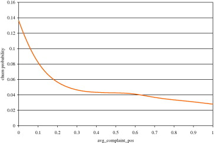

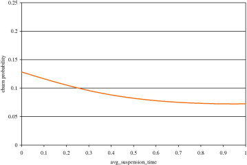

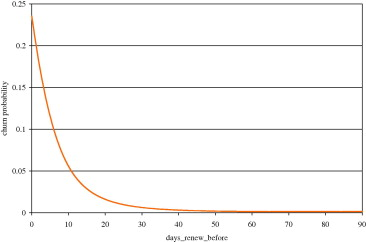

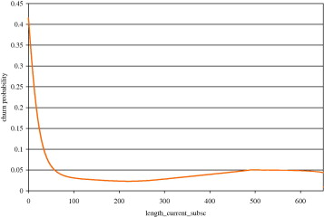

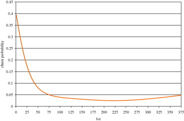

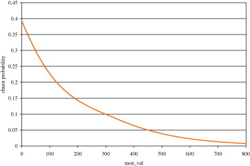

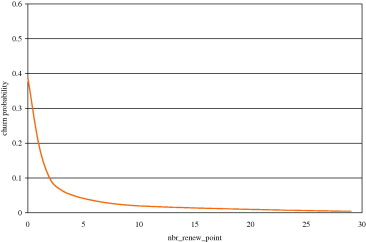

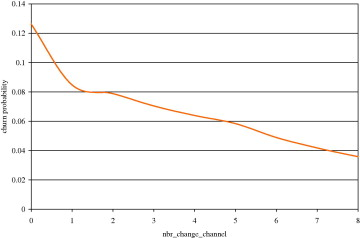

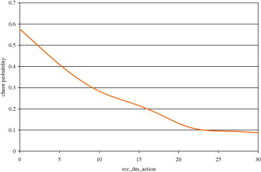

*U-trend*

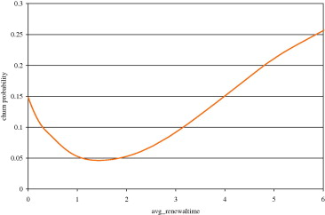

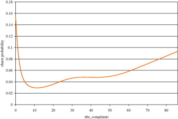

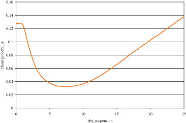

*Inverted U-trend*

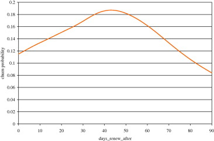

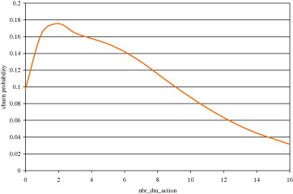

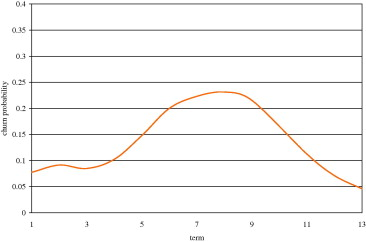

*Complex trend*

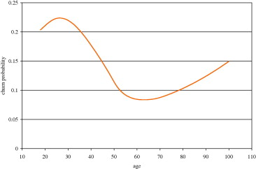

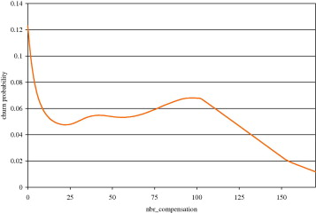

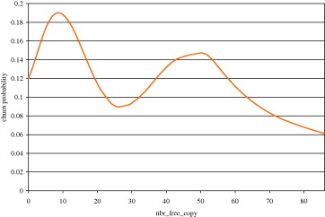

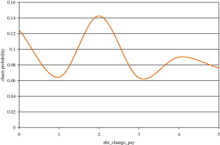

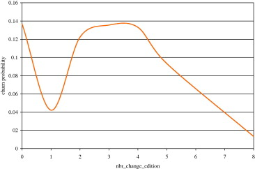

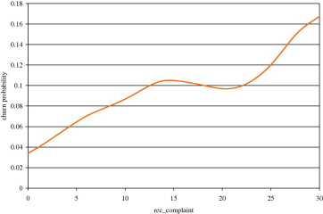

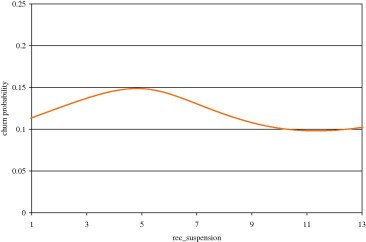

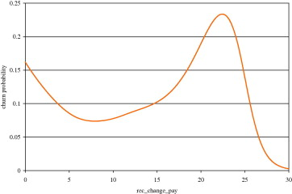

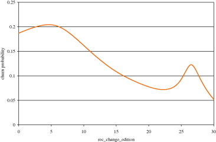

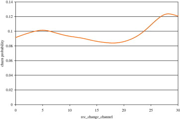

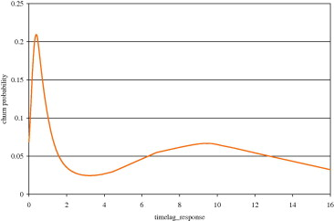

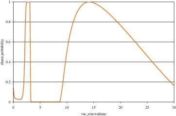

## References

**Allison, 1999**

P.D. Allison**Logistic regression using the SAS system: Theory and application**

SAS Institute Inc., Cary (1999)

[Google Scholar](https://scholar.google.com/scholar_lookup?title=Logistic%20regression%20using%20the%20SAS%20system%3A%20Theory%20and%20application&publication_year=1999&author=P.D.%20Allison)

**Anderson, 1983**

J.A. Anderson**Logistic discrimination**

P.R. Krishnaiah, L.N. Kanal (Eds.), Handbook of statistics, Vol. 2, Elsevier Science Publishing Co., New York (1983)

[Google Scholar](https://scholar.google.com/scholar_lookup?title=Logistic%20discrimination&publication_year=1983&author=J.A.%20Anderson)

**Athanassopoulos, 2000**

A.D. Athanassopoulos**Customer satisfaction cues to support market segmentation and explain switching behaviour**

Journal of Business Research, 47 (3) (2000)

Google Scholar

**Bellman, 1961**

R. Bellman**Adaptive control processes: A guided tour**

Princeton University Press (1961)

[Google Scholar](https://scholar.google.com/scholar_lookup?title=Adaptive%20control%20processes%3A%20A%20guided%20tour&publication_year=1961&author=R.%20Bellman)

**Buckinx and Van den Poel, 2005**

W. Buckinx, D. Van den Poel**Customer base analysis: partial defection of behaviourally loyal clients in a non-contractual FMCG retail setting**

European Journal of Operational Research, 164 (1) (2005)

Google Scholar

**Burez and Van den Poel, 2007**

J. Burez, D. Van den Poel**CRM at Canal + Belgique: Reducing customer attrition through targeted marketing**

Expert Systems with Applications, 32 (2) (2007), pp. 277-288

[Article](https://www.sciencedirect.com/science/article/pii/S0957417405003374)[Download PDF](https://www.sciencedirect.com/science/article/pii/S0957417405003374/pdfft?md5=5c73eeb2a3eb9bf9948ff5f28908d0d0&pid=1-s2.0-S0957417405003374-main.pdf)[View Record in Scopus](https://www.scopus.com/inward/record.url?eid=2-s2.0-33750429921&partnerID=10&rel=R3.0.0)[Google Scholar](https://scholar.google.com/scholar?q=CRM%20at%20CanalBelgique:%20Reducing%20customer%20attrition%20through%20targeted%20marketing)

**Burez and Van den Poel, 2009**

J. Burez, D. Van den Poel**Handling class imbalances in customer churn prediction**

Expert Systems with Applications, 36 (3) (2009)

[Google Scholar](https://scholar.google.com/scholar_lookup?title=Handling%20class%20imbalances%20in%20customer%20churn%20prediction&publication_year=2009&author=J.%20Burez&author=D.%20Van%20den%20Poel)

**Cakir, 2009**

O. Cakir**Benders decomposition applied to multi-commodity, multi-mode distribution planning**

Expert Systems with Applications, 36 (4) (2009)

[Google Scholar](https://scholar.google.com/scholar_lookup?title=Benders%20decomposition%20applied%20to%20multi-commodity%2C%20multi-mode%20distribution%20planning&publication_year=2009&author=O.%20Cakir)

**Coussement and Van den Poel, 2008**

K. Coussement, D. Van den Poel**Churn prediction in subscription services: An application of support vector machines while comparing two parameter-selection techniques**

Expert Systems with Applications, 34 (1) (2008), pp. 313-327

[Article](https://www.sciencedirect.com/science/article/pii/S0957417406002806)[Download PDF](https://www.sciencedirect.com/science/article/pii/S0957417406002806/pdfft?md5=942186048f1b9a6aa536115088302e29&pid=1-s2.0-S0957417406002806-main.pdf)[View Record in Scopus](https://www.scopus.com/inward/record.url?eid=2-s2.0-34248524002&partnerID=10&rel=R3.0.0)Google Scholar

**Coussement and Van den Poel, 2009**

K. Coussement, D. Van den Poel**Improving customer attrition prediction by integrating emotions from client/company interaction emails and evaluating multiple classifiers**

Expert Systems with Applications, 36 (3) (2009)

[Google Scholar](https://scholar.google.com/scholar?q=Improving%20customer%20attrition%20prediction%20by%20integrating%20emotions%20from%20clientcompany%20interaction%20emails%20and%20evaluating%20multiple%20classifiers)

**DeLong et al., 1988**

E.R. DeLong, D.M. DeLong, D.L. Clarke-Pearson**Comparing the areas under two or more correlated receiver operating characteristic curves: A nonparametric Approach**

Biometrics, 44 (3) (1988), pp. 837-845

[CrossRef](https://doi.org/10.2307/2531595)[View Record in Scopus](https://www.scopus.com/inward/record.url?eid=2-s2.0-0023710206&partnerID=10&rel=R3.0.0)Google Scholar

**Egan, 1975**

J.P. Egan**Signal detection theory and ROC analysis**

Academic Press, New York (1975)

[Google Scholar](https://scholar.google.com/scholar_lookup?title=Signal%20detection%20theory%20and%20ROC%20analysis&publication_year=1975&author=J.P.%20Egan)

**Friedman and Stuetzle, 1981**

J.H. Friedman, W. Stuetzle**Projection pursuit regression**

Journal of the American Statistical Association, 76 (1981), pp. 817-823

[View Record in Scopus](https://www.scopus.com/inward/record.url?eid=2-s2.0-84950941772&partnerID=10&rel=R3.0.0)[Google Scholar](https://scholar.google.com/scholar_lookup?title=Projection%20pursuit%20regression&publication_year=1981&author=J.H.%20Friedman&author=W.%20Stuetzle)

**Guyon and Elisseef, 2003**

I. Guyon, A. Elisseef**An introduction to variable and feature selection**

Journal of Machine Learning Research, 3 (Mar) (2003)

[Google Scholar](https://scholar.google.com/scholar_lookup?title=An%20introduction%20to%20variable%20and%20feature%20selection&publication_year=2003&author=I.%20Guyon&author=A.%20Elisseef)

**Hastie and Tibshirani, 1986**

T. Hastie, R. Tibshirani**Generalized additive models**

Statistical Science, 1 (3) (1986), pp. 297-318

[View Record in Scopus](https://www.scopus.com/inward/record.url?eid=2-s2.0-85093403289&partnerID=10&rel=R3.0.0)[Google Scholar](https://scholar.google.com/scholar_lookup?title=Generalized%20additive%20models&publication_year=1986&author=T.%20Hastie&author=R.%20Tibshirani)

**Hastie and Tibshirani, 1987**

T. Hastie, R. Tibshirani**Generalized additive models: Some applications**

Journal of the American Statistical Association, 82 (398) (1987), pp. 371-386

[View Record in Scopus](https://www.scopus.com/inward/record.url?eid=2-s2.0-84866389083&partnerID=10&rel=R3.0.0)[Google Scholar](https://scholar.google.com/scholar_lookup?title=Generalized%20additive%20models%3A%20Some%20applications&publication_year=1987&author=T.%20Hastie&author=R.%20Tibshirani)

**Hastie and Tibshirani, 1990**

T. Hastie, R. Tibshirani

Generalized additive models, Monographs on statistics and applied probability, vol. 43, Chapman and Hall (1990)

335

[Google Scholar](https://scholar.google.com/scholar_lookup?title=Generalized%20additive%20models&publication_year=1990&author=T.%20Hastie&author=R.%20Tibshirani)

**Hastie et al., 2001**

T. Hastie, R. Tibshirani, J. Friedman**The elements of statistical learning: Data mining, inference and prediction**

Springer-Verlag Series in Statistics (2001)

Google Scholar

**Hoekstra et al., 1999**

J.C. Hoekstra, P.S. Leeflang, D.R. Wittink**The customer concept: The basis for a new marketing paradigm**

Journal of Market Focused Management, 4 (1) (1999)

Google Scholar

**Horowitz and Savin, 2001**

J.L. Horowitz, N.E. Savin**Binary response models: Logits, probits and semiparametrics**

Journal of Economic Perspectives, 15 (4) (2001)

[Google Scholar](https://scholar.google.com/scholar_lookup?title=Binary%20response%20models%3A%20Logits%2C%20probits%20and%20semiparametrics&publication_year=2001&author=J.L.%20Horowitz&author=N.E.%20Savin)

**Hwang and Euiiho Suh, 2004**

H. Hwang, T. Euiiho Suh**An LTV model and customer segmentation based on customer value: A case study on the wireless telecommunications industry**

Expert Systems with Applications, 26 (2) (2004)

Google Scholar

**Jones et al., 2000**

M.A. Jones, D.L. Mothersbaugh, S.E. Beatty**Switching barriers and repurchase intentions in services**

Journal of Retailing, 76 (2) (2000)

[Google Scholar](https://scholar.google.com/scholar_lookup?title=Switching%20barriers%20and%20repurchase%20intentions%20in%20services&publication_year=2000&author=M.A.%20Jones&author=D.L.%20Mothersbaugh&author=S.E.%20Beatty)

**Jowett et al., 2008**

I.G. Jowett, S.M. Parkyn, J. Richardson**Habitat characteristics of crayfish (*Paranephrops planifrons*) in New Zealand streams using generalised additive models (GAMs)**

Hydrobiologia, 596 (1) (2008)

[Google Scholar](https://scholar.google.com/scholar?q=Habitat%20characteristics%20of%20crayfish%20%20in%20New%20Zealand%20streams%20using%20generalised%20additive%20models)

**Kalyanam and Shively, 1998**

K. Kalyanam, T.S. Shively**Estimating irregular pricing effects: A stochastic spline regression approach**

Journal of Marketing Research, 35 (1) (1998)

[Google Scholar](https://scholar.google.com/scholar_lookup?title=Estimating%20irregular%20pricing%20effects%3A%20A%20stochastic%20spline%20regression%20approach&publication_year=1998&author=K.%20Kalyanam&author=T.S.%20Shively)

**Kim, 2006**

Y.S. Kim**Toward a successful CRM: Variable selection, sampling and ensemble**

Decision Support Systems, 41 (2) (2006)

[Google Scholar](https://scholar.google.com/scholar_lookup?title=Toward%20a%20successful%20CRM%3A%20Variable%20selection%2C%20sampling%20and%20ensemble&publication_year=2006&author=Y.S.%20Kim)

**Kim and Yoon, 2004**

H. Kim, C. Yoon**Determinants of subscriber churn and customer loyalty in the Korean mobile telephony market**

Telecommunications Policy, 28 (9–10) (2004)

Google Scholar

**Kumar et al., 1998**

N. Kumar, L.K. Scheer, J.B. Steenkamp**Interdependence, punitive capability and the reciprocation of punitive actions in channel relationships**

Journal of Marketing Research, 35 (2) (1998)

Google Scholar

**Lee et al., 2007**

C.H. Lee, D.C. Wu, J.M. Lee, I.C. Wu, Y.G. Goan, E.L. Kao, *et al.***Carcinogenetic impact of alcohol intake on squamous cell carcinoma risk of the oesophagus in relation to tobacco smoking**

European Journal of Cancer, 43 (7) (2007)

Google Scholar

**Lemmens and Croux, 2006**

A. Lemmens, C. Croux**Bagging and boosting classification trees to predict churn**

Journal of Marketing Research, 43 (2) (2006)

[Google Scholar](https://scholar.google.com/scholar_lookup?title=Bagging%20and%20boosting%20classification%20trees%20to%20predict%20churn&publication_year=2006&author=A.%20Lemmens&author=C.%20Croux)

**Reichheld and Sasser, 1990**

F.F. Reichheld, W.E. Sasser Jr.**Zero defections: quality comes to service**

Harvard Business Review, 68 (5) (1990)

[Google Scholar](https://scholar.google.com/scholar_lookup?title=Zero%20defections%3A%20quality%20comes%20to%20service&publication_year=1990&author=F.F.%20Reichheld&author=W.E.%20Sasser%20Jr.)

**Reinartz and Kumar, 2002**

W.J. Reinartz, V. Kumar**The mismanagement of customer loyalty**

Harvard Business Review, 80 (July) (2002)

[Google Scholar](https://scholar.google.com/scholar_lookup?title=The%20mismanagement%20of%20customer%20loyalty&publication_year=2002&author=W.J.%20Reinartz&author=V.%20Kumar)

**Reinartz and Kumar, 2003**

W.J. Reinartz, V. Kumar**The impact of customer relationship characteristics on profitable lifetime duration**

Journal of Marketing, 67 (1) (2003)

Google Scholar

**Rosset et al., 2001**

Rosset, S., Neumann, E., Eick, U., Vatnik, N., & Idan, I., (2001). Evaluating campaign benefits and models for marketing campaigns. In Proceedings of the 7th international conference on knowledge discovery and data mining (KDD 01).

Google Scholar

**Shaffer and Zhang, 2002**

G. Shaffer, J.Z. Zhang**Competitive one-to-one promotions**

Management Science, 48 (9) (2002)

[Google Scholar](https://scholar.google.com/scholar_lookup?title=Competitive%20one-to-one%20promotions&publication_year=2002&author=G.%20Shaffer&author=J.Z.%20Zhang)

**Shaw et al., 2001**

M.J. Shaw, C. Subramaniam, G.W. Tan, M.E. Welge**Knowledge management and data mining for marketing**

Decision Support Systems, 31 (1) (2001)

Google Scholar

**Shively et al., 2000**

T.S. Shively, G.M. Allenby, R. Kohn**A nonparametric approach to identifying latent relationships in hierarchical models**

Marketing Science, 19 (2) (2000)

Google Scholar

**Stone, 1985**

C.J. Stone**Additive regression and other nonparametric models**

Annals of Statistics, 13 (1985), pp. 689-705

[CrossRef](https://doi.org/10.1214/aos/1176349548)[View Record in Scopus](https://www.scopus.com/inward/record.url?eid=2-s2.0-85086474189&partnerID=10&rel=R3.0.0)[Google Scholar](https://scholar.google.com/scholar_lookup?title=Additive%20regression%20and%20other%20nonparametric%20models&publication_year=1985&author=C.J.%20Stone)

**Tabachnick and Fidell, 1996**

B.G. Tabachnick, L.S. Fidell**Using multivariate statistics**

Harper Collings Publishers, New York (1996)

[Google Scholar](https://scholar.google.com/scholar_lookup?title=Using%20multivariate%20statistics&publication_year=1996&author=B.G.%20Tabachnick&author=L.S.%20Fidell)

**Teo et al., 2006**

T.S.H. Teo, P. Devadoss, S.L. Pan**Towards a holistic perspective of customer relationship management (CRM) implementation: A case study of the housing and development board, Singapore**

Decision Support Systems, 42 (3) (2006)

Google Scholar

**Thomas, 2001**

J.S. Thomas**A methodology for linking customer acquisition to customer retention**

Journal of Marketing Research, 38 (2) (2001)

[Google Scholar](https://scholar.google.com/scholar_lookup?title=A%20methodology%20for%20linking%20customer%20acquisition%20to%20customer%20retention&publication_year=2001&author=J.S.%20Thomas)

**Torkzadeh et al., 2006**

G. Torkzadeh, J. C.-J. Chang, G.W. Hansen**Identifying issues in customer relationship management at Merck-Medco**

Decision Support Systems, 42 (2) (2006)

Google Scholar

**Van den Poel and Larivière, 2004**

D. Van den Poel, B. Larivière**Customer attrition analysis for financial services using proportional hazard models**

European Journal of Operational Research, 157 (1) (2004), pp. 196-217

[Article](https://www.sciencedirect.com/science/article/pii/S0377221703000699)[Download PDF](https://www.sciencedirect.com/science/article/pii/S0377221703000699/pdfft?md5=5e69b309c63d6a81e82c930d84c6792e&pid=1-s2.0-S0377221703000699-main.pdf)[View Record in Scopus](https://www.scopus.com/inward/record.url?eid=2-s2.0-1842478892&partnerID=10&rel=R3.0.0)Google Scholar

[View Abstract](https://www.sciencedirect.com/science/article/abs/pii/S0957417409007325)

Copyright © 2009 Elsevier Ltd. All rights reserved.

  [Download PDF](https://www.sciencedirect.com/science/article/pii/S0957417411009237/pdfft?md5=d7964257d209760ee3fb023103b6ad26&pid=1-s2.0-S0957417411009237-main.pdf)

  [Download PDF](https://www.sciencedirect.com/science/article/pii/S0308596111000231/pdfft?md5=410a8550433b24582b98e136db418429&pid=1-s2.0-S0308596111000231-main.pdf)

  [Download PDF](https://www.sciencedirect.com/science/article/pii/S1568494614004062/pdfft?md5=dd17d223badf19ec4adbe3556be862aa&pid=1-s2.0-S1568494614004062-main.pdf)

Citations

[View details](https://plu.mx/plum/a/?doi=10.1016/j.eswa.2009.07.029&theme=plum-sciencedirect-theme&hideUsage=true)

View PDF